# Introduction to Biostatistics

# 1 Learning objectives

## 1.1 Learning objectives

- *Describe* the logic of **hypothesis testing**
- *Interpret* tests comparing **one sample** to hypothesized value
- *Relate* **hypothesis testing** to **confidence intervals**
- *Recognize* when to use a **nonparametric test**

# 2 Hypothesis testing

## 2.1 History of hypothesis testing

- William Gossett (Student)
  - $t$ distribution, $t$-test
- Sir Ronald Fisher
  - “Significance testing”
  - $p$-values, $\alpha$ = .05, $\beta$ = .2, degrees of freedom
- Jerzy Neyman, Karl Pearson, Egon Pearson
  - “Hypothesis testing”

## 2.2 Null and alternative hypotheses

- *Null* hypothesis = no effect in *population*
  - $H_0$
- *Alternative* hypothesis = effect in *population*
  - $H_1$ or $H_A$
- If there is enough evidence, we can **reject $H_0$**
  - Otherwise, we *retain* or *accept* $H_0$
  - **We cannot reject $H_A$**

## 2.3 Directional vs non-directional tests

- Directional (one-tailed) tests
  - $H_0$: $\mu \le \mu_0$
  - $H_1$: $\mu > \mu_0$
- Non-directional (two-tailed) tests
  - $H_0$: $\mu = \mu_0$
  - $H_1$: $\mu \ne \mu_0$

## 2.4 95% One tailed vs two tailed

- One-tailed test ($H_1: \mu > 0$)

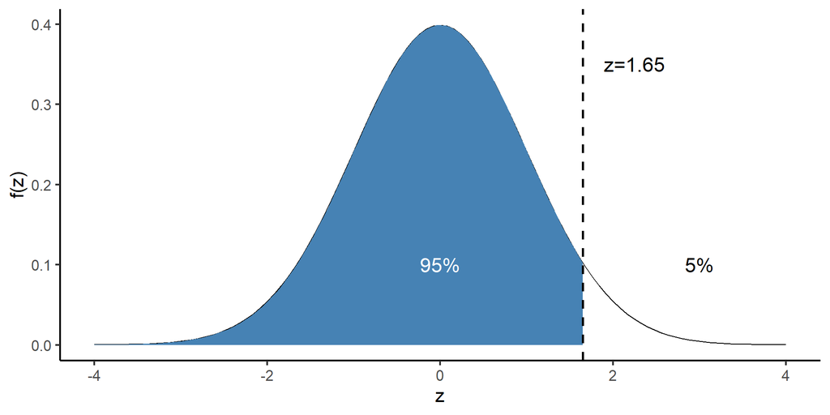

```r
ggplot(data.frame(x = c(-4, 4)), aes(x)) +
  stat_function(fun = dnorm,
                geom = "line",
                xlim = c(-4, 4)) +
  stat_function(fun = dnorm,
                geom = "area",
                fill = "steelblue",
                xlim = c(-4, 1.65)) +
  annotate("text", x = 0, y = 0.1, label = "95%", color = "white", size = 6) +
  annotate("text", x = 3, y = 0.1, label = "5%", size = 6) +
  geom_vline(xintercept = 1.65, linetype = "dashed", linewidth = 1) +
  annotate("text", x = 2.25, y = 0.35, label = "z=1.65", size = 6) +
  xlim(-4, 4) +
  labs(x = "z", y = "f(z)")
```

- Two-tailed test ($H_1: \mu \ne 0$)

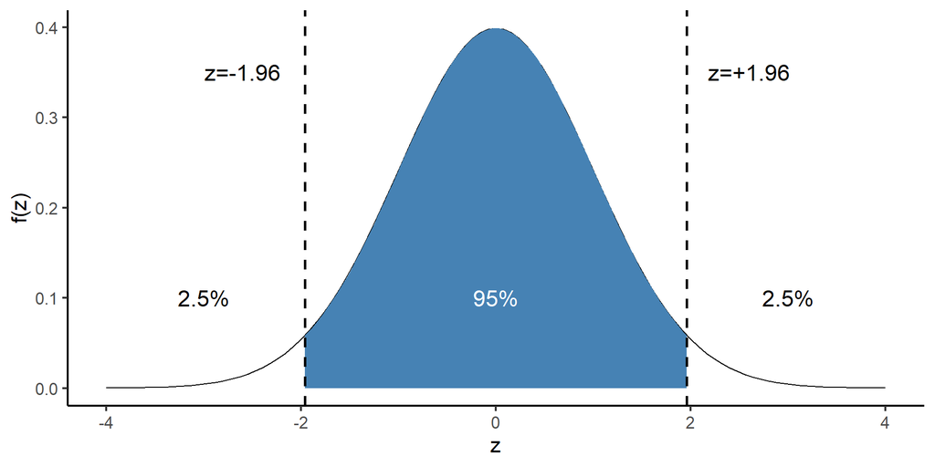

```r
ggplot(data.frame(x = c(-4, 4)), aes(x)) +
  stat_function(fun = dnorm,
                geom = "line",
                xlim = c(-4, 4)) +
  stat_function(fun = dnorm,
                geom = "area",
                fill = "steelblue",
                xlim = c(-1.96, 1.96)) +
  annotate("text", x = 0, y = 0.1, label = "95%", color = "white", size = 6) +
  annotate("text", x = 3, y = 0.1, label = "2.5%", size = 6) +
  annotate("text", x = -3, y = 0.1, label = "2.5%", size = 6) +
  geom_vline(xintercept = 1.96, linetype = "dashed", linewidth = 1) +
  geom_vline(xintercept = -1.96, linetype = "dashed", linewidth = 1) +
  annotate("text", x = 2.6, y = 0.35, label = "z=+1.96", size = 6) +
  annotate("text", x = -2.6, y = 0.35, label = "z=-1.96", size = 6) +
  xlim(-4, 4) +
  labs(x = "z", y = "f(z)")
```

## 2.5 Critical values and decisions

- **Critical value**: Distribution value that puts $\alpha$ in the tail(s)
  - i.e., $\pm$ 1.96 for a two-tailed $z$-test, 1.65 for a one-tailed $z$-test
- If the *test statistic* is more extreme than the **critical value**
  - Reject $H_0$
- Otherwise, retain $H_0$ or accept $H_0$

## 2.6 Rejection region(s)

- One-tailed test ($H_1: \mu > 0$)

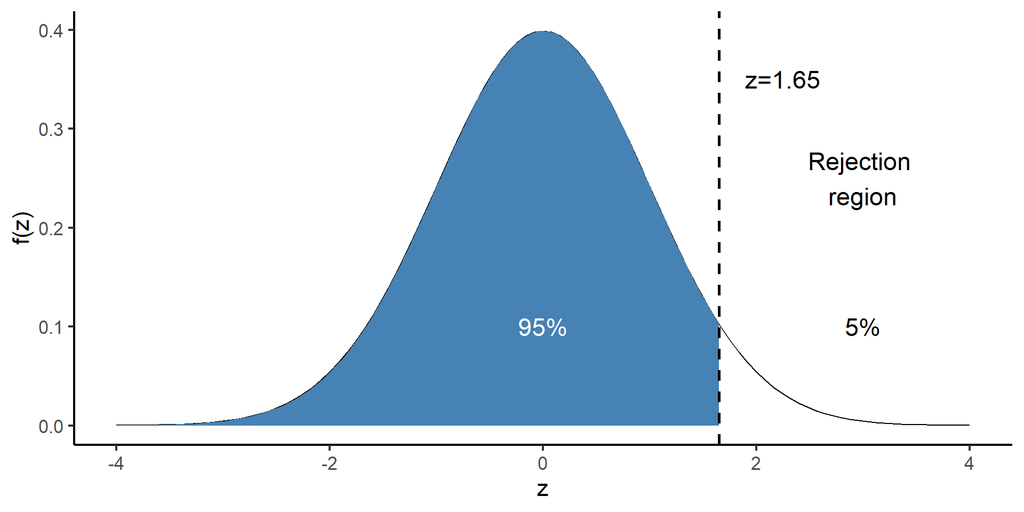

```r
ggplot(data.frame(x = c(-4, 4)), aes(x)) +
  stat_function(fun = dnorm,
                geom = "line",
                xlim = c(-4, 4)) +
  stat_function(fun = dnorm,
                geom = "area",
                fill = "steelblue",
                xlim = c(-4, 1.65)) +
  annotate("text", x = 0, y = 0.1, label = "95%", color = "white", size = 6) +
  annotate("text", x = 3, y = 0.1, label = "5%", size = 6) +
  geom_vline(xintercept = 1.65, linetype = "dashed", linewidth = 1) +
  annotate("text", x = 2.25, y = 0.35, label = "z=1.65", size = 6) +
  annotate("text", x = 3, y = 0.25, label = "Rejection \nregion", size = 6) +
  xlim(-4, 4) +
  labs(x = "z", y = "f(z)")
```

- Two-tailed test ($H_1: \mu \ne 0$)

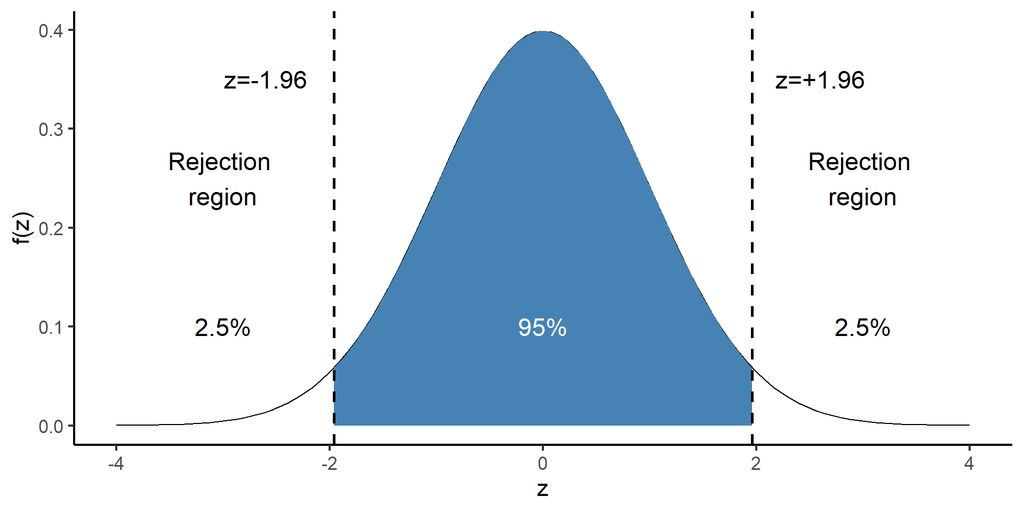

```r
ggplot(data.frame(x = c(-4, 4)), aes(x)) +
  stat_function(fun = dnorm,
                geom = "line",
                xlim = c(-4, 4)) +
  stat_function(fun = dnorm,
                geom = "area",
                fill = "steelblue",
                xlim = c(-1.96, 1.96)) +
  annotate("text", x = 0, y = 0.1, label = "95%", color = "white", size = 6) +
  annotate("text", x = 3, y = 0.1, label = "2.5%", size = 6) +
  annotate("text", x = -3, y = 0.1, label = "2.5%", size = 6) +
  geom_vline(xintercept = 1.96, linetype = "dashed", linewidth = 1) +
  geom_vline(xintercept = -1.96, linetype = "dashed", linewidth = 1) +
  annotate("text", x = 2.6, y = 0.35, label = "z=+1.96", size = 6) +
  annotate("text", x = -2.6, y = 0.35, label = "z=-1.96", size = 6) +
  annotate("text", x = 3, y = 0.25, label = "Rejection \nregion", size = 6) +
  annotate("text", x = -3, y = 0.25, label = "Rejection \nregion", size = 6) +
  xlim(-4, 4) +
  labs(x = "z", y = "f(z)")
```

## 2.7 Statistical errors

- Any statistical decision has some probability of being an **error**
  - **Type I error**: *Detecting* an effect in the sample that *doesn’t exist in the population*
  - **Type II error**: *Not detecting* an effect in the sample that *does exist in the population*

|  | Effect in population | No effect in population |
| --- | --- | --- |
| Effect in sample | Correct | Type I error ($\alpha$) |
| No effect in sample | Type II error ($\beta$) | Correct |

## 2.8 Alpha ($\alpha$)

- $\alpha$ = Probability of type I error
  - P(*incorrectly detecting* an effect that *doesn’t exist* in the population)
- Typical $\alpha$ values: **.05**, .01, .001
  - Correspond to 95%, 99%, 99.9% confidence levels, respectively
- Fisher: Type I error should happen 1 time in 20 $\rightarrow$ $\alpha$ = .05

## 2.9 Beta ($\beta$)

- $\beta$ = Probability of type II error
  - P(*incorrectly missing* an effect that *exists* in the population)
- Statistical power = $1 - \beta$
  - Probability of correctly detecting an effect that does exist
- Typical $\beta$ values: **.2**, .1
  - Correspond to .8, .9 power, respectively
- Fisher: Type II:Type I ratio = 4 $\rightarrow$ 0.2:0.05 = 4

# 3 One sample tests

## 3.1 One sample tests

- Compare *one sample mean* to a *hypothesized population mean value*
- Reject $H_0$
  - Sample is **unlikely** to have come from a population with that mean
- Retain $H_0$
  - Sample **could have** come from a population with that mean
- Three tests here: $z$-test, $t$-test, binomial test

## 3.2 $z$-test: Assumptions

- Data are **continuous** (i.e., ratio or interval)
- Data are **randomly sampled** from the population
- Data are **independent**
- Data are **approximately normally distributed** **OR** sample size is large enough for **normally distributed sampling distribution** (*central limit theorem*)
- Population variance (or standard deviation) is **known**

## 3.3 $z$-test: Hypotheses

- Directional (one-tailed) tests
  - $H_0$: $\mu \le \mu_0$
  - $H_1$: $\mu > \mu_0$
- Non-directional (two-tailed) tests
  - $H_0$: $\mu = \mu_0$
  - $H_1$: $\mu \ne \mu_0$

## 3.4 $z$-test: Test statistic

$$z = \frac{\bar{X} - \mu_0}{\sigma /\sqrt{n}}$$

- *Sample mean* minus *hypothesized population mean*, divided by **standard error**
  - Standard error is the **standard deviation** of the *sampling distribution*

## 3.5 $z$-test: Decision

- Determine critical value for $\alpha$
  - e.g., 1.96 for 2-tailed test at $\alpha = .05$
- If observed $z$ statistic is **more extreme** than the critical value
  - Reject $H_0$
- Otherwise, retain $H_0$

## 3.6 $z$-test: Example 1

- Sample of $n$ = 50
- **Known population SD** = 15
- Does this sample come from a population with a mean of 100?
- Two-tailed test
  - $H_0$: $\mu = 100$
  - $H_1$: $\mu \ne 100$

```r
sample1 <- rnorm(n = 50, mean = 103, sd = 15)
```

## 3.7 $z$-test: Example 2

$$z = \frac{\bar{X} - \mu_0}{\sigma /\sqrt{n}}$$

```r
mean(sample1)
```

```
[1] 105.6935
```

```r
z <- (mean(sample1) - 100) / (15 / sqrt(50))
z
```

```
[1] 2.683939
```

- Two tailed test, $\alpha$ = .05: Critical value = 1.96
  - Is the observed test statistic greater than +1.96 or lower than -1.96?
  - If yes, reject $H_0$

## 3.9 $z$-test: Example 4

```r
library(BSDA)
z.test(x = sample1,
       alternative = "two.sided",
       mu = 100,
       sigma.x = 15,
       conf.level = .95)
```

```
    One-sample z-Test

data:  sample1
z = 2.6839, p-value = 0.007276
alternative hypothesis: true mean is not equal to 100
95 percent confidence interval:
 101.5358 109.8512
sample estimates:
mean of x
 105.6935
```

## 3.10 $z$-test: Report results

- $p$-value < .05 and 95% confidence interval don’t contain 100
  - Reject $H_0: \mu = 100$
  - This sample came from a population with a **different mean**
- Using a **one sample $z$-test**, we rejected the null hypothesis that $\mu$ = 100, $z$ = 2.684, $p$ = 0.007.

## 3.11 What is the $p$-value?

- P(detecting an effect this large or larger **if the null hypothesis is true**)

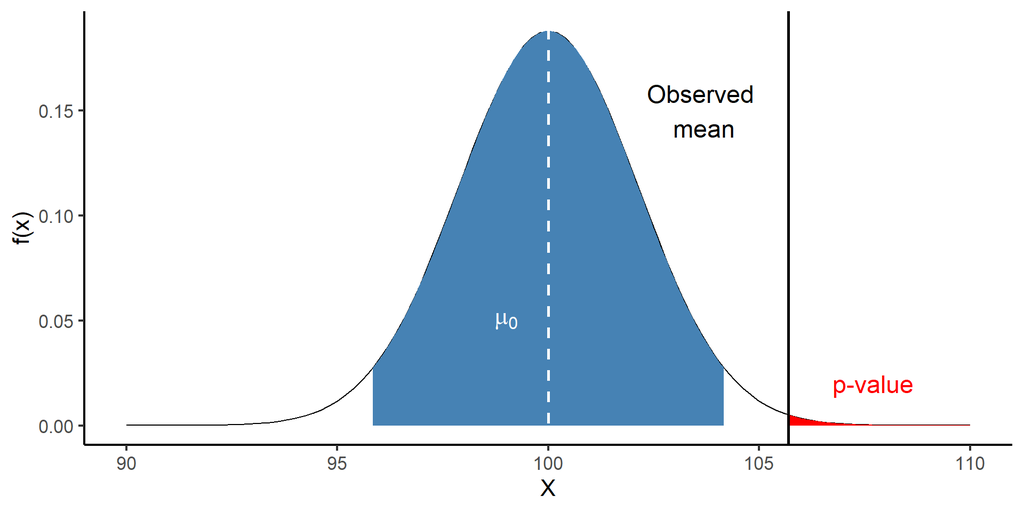

```r
mu0 <- paste0("mu[0]")
ggplot(data.frame(x = c(90, 110)), aes(x)) +
  stat_function(fun = dnorm,
                args = list(mean = 100, sd = 15/sqrt(50)),
                geom = "line",
                xlim = c(90, 110)) +
  stat_function(fun = dnorm,
                args = list(mean = 100, sd = 15/sqrt(50)),
                geom = "area",
                fill = "steelblue",
                xlim = c(100 - 1.96*15/sqrt(50), 100 + 1.96*15/sqrt(50))) +
  stat_function(fun = dnorm,
                args = list(mean = 100, sd = 15/sqrt(50)),
                geom = "area",
                fill = "red",
                xlim = c(mean(sample1), 110)) +
  geom_vline(xintercept = mean(sample1), linewidth = 1) +
  annotate("text", x = mean(sample1) - 2, y = 0.15, label = "Observed \nmean", size = 6) +
  annotate("text", x = mean(sample1) + 2, y = 0.02, label = "p-value", size = 6, color = "red") +
  geom_vline(xintercept = 100, linewidth = 1, color = "white", linetype = "dashed") +
  annotate("text", x = 99, y = 0.05, label = mu0, size = 6, color = "white", parse = TRUE) +
  xlim(90, 110) +
  labs(x = "X", y = "f(x)")
```

## 3.12 $t$-test: Assumptions

- Data are **continuous** (i.e., ratio or interval)
- Data are **randomly sampled** from the population
- Data are **independent**
- Data are **approximately normally distributed** **OR** sample size is large enough for **normally distributed sampling distribution** (*central limit theorem*)
- Population variance (or standard deviation) is **unknown**

## 3.13 Unknown population variance

- Population variance is *not known* when using a $t$-test
  - So we *estimate* it with the *sample variance*

| Estimate | Definition | Computational |
| --- | --- | --- |
| Population variance ($\sigma^2$) | $\frac{\sum (X - \mu)^2}{N}$ | $\frac{\sum X^2 - \frac{(\sum X)^2}{N}}{N}$ |
| Sample variance ($s^2$) | $\frac{\sum (X - \overline{X})^2}{n-1}$ | $\frac{\sum X^2 - \frac{(\sum X)^2}{n}}{n-1}$ |

## 3.14 $t$-test: Hypotheses

- Directional (one-tailed) tests
  - $H_0$: $\mu \le \mu_0$
  - $H_1$: $\mu > \mu_0$
- Non-directional (two-tailed) tests
  - $H_0$: $\mu = \mu_0$
  - $H_1$: $\mu \ne \mu_0$

## 3.15 $t$-test: Test statistic

$$t = \frac{\bar{X} - \mu_0}{s /\sqrt{n}}$$

- *Sample mean* minus *hypothesized population mean*, divided by **standard error**
  - Standard error is the **standard deviation** of the *sampling distribution*

## 3.16 Degrees of freedom

- How many independent pieces of information do we have?
  - In general, this is the sample size ($n$)
- But if we estimate something (e.g., $\bar{X}$) and then **use that** to estimate something else (e.g., $s^2$), we have **less information**
  - Once you know $n - 1$ values and the mean, you know everything
- Degrees of freedom **quantify** how much *independent information*

## 3.17 Degrees of freedom: $t$ distribution

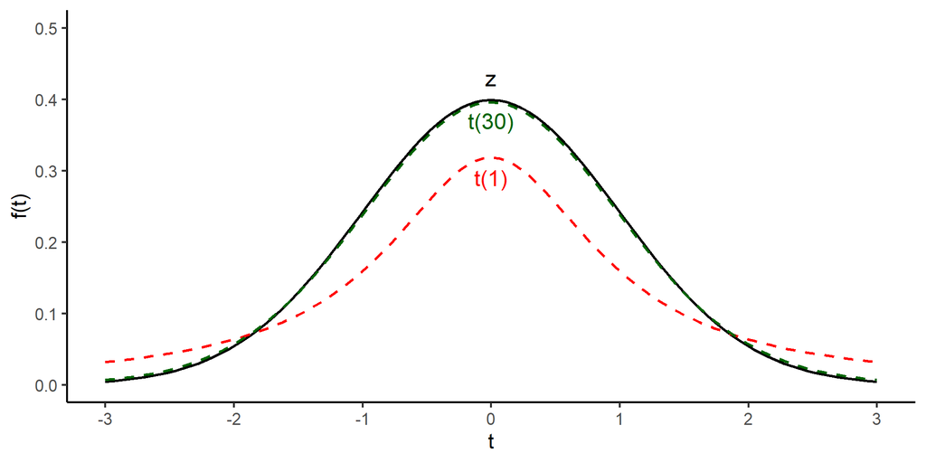

```r
ggplot(data.frame(x = c(-3, 3)), aes(x)) +
  stat_function(fun = dnorm, args = list(mean = 0, sd = 1), geom = "line", color = "black", linewidth = 1) +
  stat_function(fun = dt, args = list(df = 1, ncp = 0), geom = "line", color = "red", linewidth = 1, linetype = "dashed") +
  stat_function(fun = dt, args = list(df = 30, ncp = 0), geom = "line", color = "darkgreen", linewidth = 1, linetype = "dashed") +
  ylim(0,.5) +
  scale_x_continuous(breaks = -3:3) +
  annotate("text", x = 0, y = 0.29, label = "t(1)", color = "red", size = 6) +
  annotate("text", x = 0, y = 0.37, label = "t(30)", color = "darkgreen", size = 6) +
  annotate("text", x = 0, y = 0.43, label = "z", color = "black", size = 6) +
  labs(x = "t", y = "f(t)")
```

## 3.18 $t$-test: Decision

- Determine critical value for $\alpha$ **and degrees of freedom**
  - Degrees of freedom = $n - 1$
- If observed $t$ statistic is **more extreme** than the critical value
  - Reject $H_0$
- Otherwise, retain $H_0$

## 3.19 $t$-test: Example 1

- Same data as for $z$-test
- Sample of $n$ = 50
- **Unknown population SD**
- Does this sample come from a population with a mean of 100?
- Two-tailed test
  - $H_0$: $\mu = 100$
  - $H_1$: $\mu \ne 100$

## 3.20 $t$-test: Example 2

$$t = \frac{\bar{X} - \mu_0}{s /\sqrt{n}}$$

```r
mean(sample1)
```

```
[1] 105.6935
```

```r
t <- (mean(sample1) - 100) / (sd(sample1) / sqrt(50))
t
```

```
[1] 2.447541
```

- Two tailed test, $\alpha$ = .05, df = 49: Critical value = 2.01
  - Is the observed test statistic greater than +2.01 or lower than -2.01?
  - If yes, reject $H_0$

## 3.21 $t$-test: Example 3

- Another option: `t.test()` function in **stats** package
  - `x`: Data
  - `alternative`: “two.sided” (default), “greater”, or “less”
  - `mu`: Hypothesized population mean ($\mu_0$)
  - `conf.level`: Confidence level (default = .95)

## 3.22 $t$-test: Example 4

```r
t.test(x = sample1,
       alternative = "two.sided",
       mu = 100,
       conf.level = .95)
```

```
    One Sample t-test

data:  sample1
t = 2.4475, df = 49, p-value = 0.01801
alternative hypothesis: true mean is not equal to 100
95 percent confidence interval:
 101.0188 110.3682
sample estimates:
mean of x
 105.6935
```

## 3.23 $t$-test: Report results

- $p$-value < .05 and 95% confidence interval don’t contain 100
  - Reject $H_0: \mu = 100$
  - This sample came from a population with a different mean
- Using a **one sample $t$-test**, we rejected the null hypothesis that $\mu$ = 100, $t(49)$ = 2.448, $p$ = 0.018

## 3.24 Compare $z$-test and $t$-test

|  | $z$-test | $t$-test |
| --- | --- | --- |
| Sample mean | 105.69 | 105.69 |
| Population SD | 15 (known) | 16.45 (estimated) |
| Test statistic | 2.684 | 2.448 |
| Degrees of freedom | N/A | 49 |
| Critical value | 1.96 | 2.01 |
| $p$-value | 0.007 | 0.018 |
| Decision | Reject $H_0$ | Reject $H_0$ |

## 3.25 $\mathcal{N}(0, 1)$ vs $t(49)$

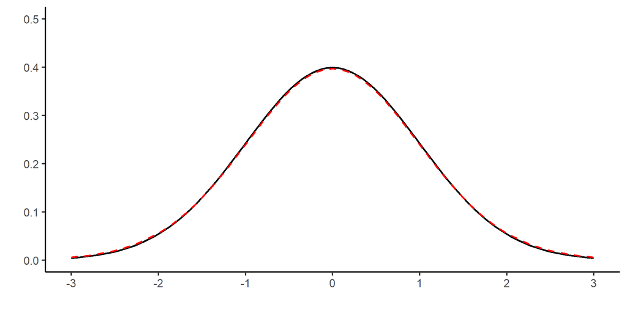

```r
ggplot(data.frame(x = c(-3, 3)), aes(x)) +
  stat_function(fun = dnorm, args = list(mean = 0, sd = 1), geom = "line", color = "black", linewidth = 1) +
  #stat_function(fun = dt, args = list(df = 1, ncp = 0), geom = "line", color = "red", linewidth = 1, linetype = "dashed") +
  #stat_function(fun = dt, args = list(df = 10, ncp = 0), geom = "line", color = "darkgreen", linewidth = 1, linetype = "dashed") +
  stat_function(fun = dt, args = list(df = 49, ncp = 0), geom = "line", color = "red", linewidth = 1, linetype = "dashed") +
  ylim(0,.5) +
  scale_x_continuous(breaks = -3:3) +
  labs(x = "", y = "")
```

## 3.26 Binomial test: Assumptions

- Data are **binomial** (i.e., several 0,1 Bernoulli trials)
  - With same probability of success ($p$) for each trial
- Data are **randomly sampled** from the population
- Data are **independent**

## 3.27 Binomial test: Hypotheses

- Directional (one-tailed) tests
  - $H_0$: $\pi \le \pi_0$
  - $H_1$: $\pi > \pi_0$
- Non-directional (two-tailed) tests
  - $H_0$: $\pi = \pi_0$
  - $H_1$: $\pi \ne \pi_0$

## 3.28 Binomial test: Test and decision

$P(X = x) = {m \choose x} p^x (1 - p)^{m -x}$

- **Binomial test** uses the *binomial distribution*
  - Exact test
  - Does not require “large” sample
  - Compare observed proportion (i.e., number of successes) to binomial distribution with hypothesized $m$ and $p$

## 3.29 Binomial test: Example 1

- Sample of $n$ = 50 coin flips
- Does this sample come from a fair coin ($\pi$ = 0.5)?
- Two-tailed test
  - $H_0$: $\pi = 0.5$
  - $H_1$: $\pi \ne 0.5$

```r
sample2 <- rbinom(50, 1, 0.53)
table(sample2)
```

```
sample2
 0  1
30 20
```

## 3.30 Binomial test: Example 2

$P(X = x) = {m \choose x} p^x (1 - p)^{m - x}$

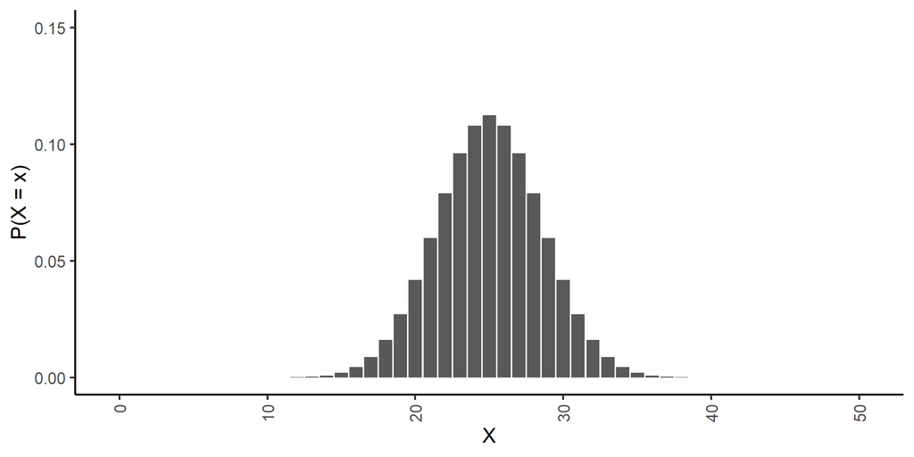

```r
binom_dat <- data.frame(x = 0:50, y = dbinom(0:50, 50, 0.5))
ggplot(data = binom_dat, aes(x = x, y = y)) +
  geom_col() +
  #scale_x_continuous(breaks = 0:50) +
  ylim(0,0.15) +
  labs(x = "X", y = "P(X = x)") +
  theme(axis.text.x = element_text(angle = 90, vjust = 0.5, hjust=1))
```

## 3.31 Binomial test: Example 3

- `binom.test()` function from **stats** package
  - `x`: number of successes
  - `n`: sample size
  - `p`: hypothesized probability of success (median = 50th %ile)
  - `alternative`: “two.sided” (default), “less”, “greater”

## 3.32 Binomial test: Example 4

```r
binom.test(x = sum(sample2 > 0),
           n = length(sample2),
           p = 0.5,
           alternative = "two.sided")
```

```
    Exact binomial test

data:  sum(sample2 > 0) and length(sample2)
number of successes = 20, number of trials = 50, p-value = 0.2026
alternative hypothesis: true probability of success is not equal to 0.5
95 percent confidence interval:
 0.2640784 0.5482060
sample estimates:
probability of success
                   0.4
```

## 3.33 Binomial test: Report results

- $p$-value > .05 and 95% confidence interval contain 0.5
  - Retain $H_0: \pi = 0.5$
  - This sample came from a population with mean = 0.5
- Using a **binomial test**, we retained the null hypothesis that $\pi$ = 0.5, observed mean = 0.4, $p$ = 0.2026.

## 3.34 Alternative: $z$-test for proportion

- Proportion = mean of binary (i.e., Bernoulli) variable
  - $z$-test as test of proportion
- Observed distribution is not normal
  - **Sampling distribution** is normal with a “large” sample
  - *Approximate* test based on assumption of normality
- Assumptions, hypotheses, critical values are the same as $z$-test
  - Replace $\mu$ with $\pi$ and $\bar{X}$ with $p$

## 3.35 Proportion: $z$-test statistic

$$z = \frac{p - \pi_0}{\sqrt{\pi_0(1-\pi_0)/n}}$$

- If $H_0$ is true
  - Population mean = $\pi_0$
  - Population variance = $\pi_0(1-\pi_0)$
- Works best when $p$ and $\pi$ are between 0.2 and 0.8

# 4 Non-parametric tests

## 4.1 Parametric vs non-parametric tests

- Parametric = following a distribution
  - e.g., sampling distribution of the mean is **normally distributed**
- Non-parametric = not following a distribution
  - Don’t assume any particular **sampling distribution**
  - Often assume the **variables** don’t have a particular distribution

## 4.2 Non-parametric tests

- Many non-parametric tests
  - Not well organized or named
- Two commonly used one sample non-parametric tests
  - Sign test: Test of median for ordinal+ data
  - Wilcoxon signed rank test: Test of median for interval+ data

## 4.3 Why non-parametric tests?

- Non-numeric data (i.e., nominal or ordinal)
- Continuous but very non-normal variables
- **Especially** with smaller samples, where CLT doesn’t apply
- Note that **parametric** tests are *more powerful* than **non-parametric** tests if their assumptions are met

## 4.4 Sign test: Assumptions

- Data are **at least ordinal** (ordinal, interval, or ratio)
- Data are **randomly sampled** from the population
- No assumptions about distribution of the data
- No assumptions about sampling distribution of the median
- Hypotheses are about **median**

## 4.5 Sign test: Logic

- Count observations **above** and **below** hypothesized median
  - If observed median = population median: 50% above, 50% below
- Compare to *binomial distribution* to determine probability of observed number of “successes”

## 4.6 Sign test: Example

- `binom.test()` function from **stats** package
  - `x`: number of successes (here, values > hypothesized median)
  - `n`: sample size
  - `p`: hypothesized probability of success (median = 50th %ile)
  - `alternative`: “two.sided” (default), “less”, “greater”

## 4.7 Sign test: Example

```r
binom.test(x = sum(sample1 > 100),
           n = length(sample1),
           p = 0.5,
           alternative = "two.sided")
```

```
    Exact binomial test

data:  sum(sample1 > 100) and length(sample1)
number of successes = 32, number of trials = 50, p-value = 0.06491
alternative hypothesis: true probability of success is not equal to 0.5
95 percent confidence interval:
 0.4919314 0.7708429
sample estimates:
probability of success
                  0.64
```

## 4.8 Wilcoxon Signed rank test: Assumptions

- Data are **at least interval** (interval or ratio)
- Data are **randomly sampled** from the population
- No assumptions about distribution of the data
- No assumptions about sampling distribution of the median
- Hypotheses are about **median**

## 4.9 Signed rank test: Logic

- Rank **absolute values** of all values
- Above hypothesized median: Assign “+”
- Below hypothesized median: Assign “-”
- Add positive ranks, add negative ranks
- Compare to distribution under the null hypothesis
  - i.e., sum of positive ranks = sum of negative ranks

## 4.10 Signed rank test: Example

- `wilcox.test()` function from **stats** package

```r
median(sample1)
```

[output not shown]

```r
wilcox.test(sample1, mu = 100, alternative = "two.sided")
```

```
    Wilcoxon signed rank test with continuity correction

data:  sample1
V = 877, p-value = 0.02105
alternative hypothesis: true location is not equal to 100
```

# 5 Summary

## 5.1 Hypothesis testing

- Null and alternative hypotheses
  - Retain or reject $H_0$
- Hypotheses are about the **population** value (mean, median, etc.)
  - We use the sample to make **inference** about the population
- If we reject $H_0$, that just means that it’s **very unlikely** that the sample came from a population with that mean
  - We can still make a type I error

## 5.2 Deciding on a test

- Normal outcome, known $\sigma^2$: $z$-test
- Normal outcome, unknown $\sigma^2$: $t$-test
- Proportion: Binomial test for small sample, $z$-test for large sample
- Ordinal or very non-normal, especially with small sample: Non-parametric test

# 6 In-class activities

## 6.1 In-class activities

- Assess some hypotheses about some variables
  - What type of variable?
  - What type of test?
  - What do we conclude?

## 6.2 Next week

- Tests for two unrelated samples
- Tests for two related samples
- Chi-square test of independence for two binary variables